# Genetic diversity: practical

Lewis Spurgin

## Introduction

The aim of this practical is to get you estimating genomic diversity from large SNP data files. We will first become comfortable reading and subsetting very large data files. We will then use VCFtools to estimate some common measures of genetic diversity in individuals and populations. We will then develop our skills in R to manipulate our output files from plink and VCFtools. Finally, we will introduce ggplot2, and learn how to use this package to produce publication quality figures of our data.

Once again, you should try to figure things out for yourself before clicking on “show”. To do this, you will need the documentation for VCFtools open. It can be found at https://vcftools.github.io/man_latest.html

## The data

We will be working with some of my own genomic data obtained from experimentally evolved populations the red flour beetle *Tribolium castaneum*. The data file includes SNP information (in vcf format) from six resequenced genomes. Three of these individuals come from a population that has been experimentally evolved under male-biased sex ratios for ~80 generations, while the other three come from a population with a female-biased sex ratio (see Lumley et al. 2015, *Nature* for details of the experimental lines). We wish to know whether levels of genomic diversity differs between these two populations as a result of differing patterns of sexual selection.

## Instructions

Log onto the Amazon EC2 server and copy the `genetic_diversity` folder to your home directory as follows.

```r
cd
cp -r Dati/genetic_diversity .
```

Now navigate to your newly copied genetic diversity using `cd genetic_diversity` and look at what files you have. You should see two files. `TriboliumSSGenomes.vcf` and `Tribolium_sample_names.csv`. We can’t open these files in the server, but we can explore their properties and look at them using the command line. Try to do the following:

1. Find out the size of each of the two files
2. Print the contents of `Tribolium_sample_names.csv` to the terminal
3. Print the first 11 lines of `TriboliumSSGenomes.vcf` to the terminal

```bash
ls -l #Get info for all file in directory, including file size - could also use wc (word count)
cat Tribolium_sample_names.csv #Print file to console
head -n 11 TriboliumSSGenomes.vcf #Get first 11 lines
```

Before calculating heterozygosity, we will first check that the file can be read into the program. Try reading in the data into VCFtools without performing any additional operations.

```r
vcftools --vcf TriboliumSSGenomes.vcf
```

What does VCFtools give you? What do you now know about the dataset?

The two most basic ways that we can estimate genetic diversity using vcftools are i) by estimating the number of heterozygous sites (and an inbreeding coefficient) for each individual, and ii) by estimating observed and expected heterozygosity for each marker. Can you find the command for each of these and run them on the “TriboliumSSGenomes.vcf” dataset. Remember to specify a suitable output name.

```r
vcftools --vcf TriboliumSSGenomes.vcf --het --out TriboliumSSGenomes
vcftools --vcf TriboliumSSGenomes.vcf --hardy --out TriboliumSSGenomes
```

Now use `ls -l`, `head`, `cat`,`less` etc., as appropriate, to explore the output files from each of these analyses. What have the analyses done? Have you noticed any problems with the way the analyses have been performed?

Hopefully you did noticed that the `.hwe` file was very large and didn’t try to use `cat` to look at it! Using `head` we can see that the `--hardy` analysis has calculated observed and expected heterozygosity for every SNP. However, we it has averaged over our two populations for this. **Before reading on**, try to figure out how you would perform this analysis separately for each population. Then discuss with a neighbour whether you think this analysis is appropriate for this dataset (clue - think sample sizes), and think of other appropriate analyses.

We are now going to perform some analyses of nucleotide diversity. If you look at the vcftools documentation you will see that there are two options for this. We can either calculate nucleotide diversity on a “per site” basis, or in “windows” of a defined size. With just three individuals per population, per-site based measures of diversity (including the `--hardy` analysis performed just now) are problematic as each site is extremely limited in the possible values that can be obtained. We can get around this using windows. Discuss with a neighbour what is meant by “windows” and why they might be preferable to per-site measured of diversity in this instance.

We would like to calculate diversity in non-overlapping 200kb windows for each of our two populations. Can you figure out how to do this in vcftools?

For a hint, see the box below.

```r
#You will need the following commands, and to look at the Tribolium_sample_names.csv file
--window-pi
--indv
```

For the answer, see here:

```r
#For the male-biased population
vcftools --vcf TriboliumSSGenomes.vcf --window-pi 200000 --indv 2014_SOL_MG4955 --indv 2014_SOL_MG4956 --indv 2014_SOL_MG4957 --out TriboliumSSGenomesMB

#For the female-biased population
vcftools --vcf TriboliumSSGenomes.vcf --window-pi 200000 --indv 2014_SOL_MG4972 --indv 2014_SOL_MG4973 --indv 2014_SOL_MG4974 --out TriboliumSSGenomesFA
```

Hopefully you figured out that individuals 2014_SOL_MG4955, 2014_SOL_MG4956 and 2014_SOL_MG4957 are from the MB population, while the remaining individuals are from the FA population. Once you have run the above code, use the command line to take a look at the format of the output files vcftools has returned. Does it makes sense?

Before we have a go at plotting our data, we will first calculate one more measure of genetic diversity - linkage disequilibrium. Our aim is to look at how LD decays with physical distance between SNPs, and to see whether this relationship varies between our two populations. Lower levels of LD and faster rates of LD decay are typically found in large, outbred populations, whereas in small bottlenecked populations background levels of LD are higher and LD decays much more slowly.

Because LD is calculated between *pairs* of markers, the number of calculations VCFtools would have to perform for a whole genome dataset would be huge, and unnecessary for our purposes here. We will therefore restrict our analyses to i) a single chromosome (ChLG1), ii) pairs of markers within 100 kb of each other, and iii) pairs of markers with R2 values > 0.001. Using this information, can you calculate LD for both the MB and FA populations? Answer below.

```r
vcftools --vcf TriboliumSSGenomes.vcf --geno-r2 --chr ChLG1 --ld-window-bp 100000 --min-r2 0.001 --indv 2014_SOL_MG4955 --indv 2014_SOL_MG4956 --indv 2014_SOL_MG4957 --out TriboliumSSGenomesMB

vcftools --vcf TriboliumSSGenomes.vcf --geno-r2 --chr ChLG1 --ld-window-bp 100000 --min-r2 0.001 --indv 2014_SOL_MG4972 --indv 2014_SOL_MG4973 --indv 2014_SOL_MG4974 --out TriboliumSSGenomesFA
```

Use `ls - l` to look at the size of the output files. You will see that they are *huge*. Even with our restrictions, we have more than 50 million rows in each of our files. So instead of downloading this onto our laptops for plotting, we will perform a bit of extra processing on the data in the server, using R. Open up a text editor (or R studio) and save an R script using a suitable name. Then, on the Amazon server, start up R. We are going to type our instructions into a script, so we have a record of what we’ve done, but at the same time we will use the console interactively. First, we need to load a library. At the top of your script, add the following code, then copy and paste the command into your console:

```r
R
library(tidyverse)
```

Now use `read_delim()` to read in the two `.geno.ld` files you have created (one for each population), and assign each data frame to a different object name.

```r
MB <- read_delim("TriboliumSSGenomesMB.geno.ld", delim = "\t")
FA <- read_delim("TriboliumSSGenomesFA.geno.ld", delim = "\t")
```

Have a look at what’s contained in these data files by typing in their names. You will see that they are very large indeed. Each row contains the LD statistic and other information for a pair of SNPs. There are five columns: the chromosome that the two SNPs are on, the positions (in bp) of the two SNPs, the number of individuals tested, and the R2 value. We want to plot how R2 declines with the physical distance between pairs of SNPs. However, we can’t plot all of our data as i) there’s too much, and ii) with three individuals the R2 values are two noisy. So as before, we are going to use windowed averages. This time we will use 1000bp windows, as the maximum distance between any pair of SNPs in our data is 100,000. Our aim is to reduce our two data files each containing millions of LD measures to a single data file with 100 averaged LD measures for each population.

The first thing we wish to do is calculate the physical distance between each pair of SNPs. This can be obtained by subtracting the SNP positions.

```r
MB$dist <- MB$POS2 - MB$POS1
FA$dist <- FA$POS2 - FA$POS1
```

However, we do not actually want to know the exact distance between each pair of SNPs, but rather the distance rounded *up* to the nearest 1000 bp. Rather than create an extra variable, we can modify our previous command to obtain the distance between each pair of SNPs rounded up to the nearest 1kb.

For a hint of how to do this click here:

```r
x <- 1550
ceiling(x/1000)*1000
```

For an answer click here:

```r
MB$dist <- ceiling((MB$POS2 - MB$POS1)/1000)*1000
FA$dist <- ceiling((FA$POS2 - FA$POS1)/1000)*1000
```

Now we need to obtain the mean R2 value for each 1000bp distance bin. For this we are going to use the `group_by()` and `summarise()` functions in the tidyverse package `dplyr`. These functions allow us to perform functions on variables tibbles (e.g. calculate means), and return the output in a simplified tibble. Have a look at the relevant help pages and try searching for help online. Here is a tutorial:

https://datacarpentry.org/R-genomics/04-dplyr.html#split-apply-combine_data_analysis_and_the_summarize()_function

If you have not come across pipes before, you may want to read some of the previous sections on the above webpage. When you think you understand how it works, have a go at using these functions to create a new data frame with averaged R2 values for each 1000bp window. Two ways of doing this are presented below.

```r
###################
#Option 1 - uses lots of variable names
###################

MB2 <- group_by(MB,dist) %>%
  summarise(meanR2 = mean(`R^2`))

FA2 <- group_by(FA,dist) %>%
  summarise(meanR2 = mean(`R^2`))

dd <- bind_rows(MB2,FA2) #Combines

dd$pop <- rep(c("MB","FA"),c(nrow(MB2),nrow(FA2))) #Adds a population column


###################
#Option 2 - the tidyverse way
###################

dd <-   MB %>%
  group_by(dist) %>%
  summarise(meanR2 = mean(`R^2`)) %>%
  mutate(pop = "MB") %>%
  bind_rows(FA %>%
  group_by(dist) %>%
  summarise(meanR2 = mean(`R^2`)) %>%
  mutate(pop = "FB"))



#Write output
write_csv(dd,"TriboliumSSGenomes.windowed.ld.csv")
```

Have a look at one of your resulting outputs. Does it all make sense?

That’s our analyses done! Now you can log out of the server, and use SCP to download the genetic results that you have just created. To recap, you should download the files for:

- individual heterozygosity (one file, one value per individual),
- windowed nucleotide diversity (two files - one per population),
- windowed LD (one file).

Make a new folder called “session_3_output” or something similar using `mkdir` and copy the relevant files into this folder. Download your folder containing the four genetic diversity outputs using `scp` (mac) or `pscp` (windows), in exactly the same way as you learned this morning. Once you have done this, open R studio on your laptop and use `read_csv()` and `read_delim()` as appropriate to read in your newly created and downloaded data files to four suitably-named objects.

```r
rm(list=ls()) #Clear your workspace

library(tidyverse) #load the tidyverse

setwd("~/OneDrive - University of East Anglia/Documents/Teaching/PopGenBerlinLGS/session_3_output/")

het <- read_delim("TriboliumSSGenomes.het",delim = "\t")
pi_MB <- read_delim("TriboliumSSGenomesMB.windowed.pi",delim = "\t")
pi_FA <- read_delim("TriboliumSSGenomesFA.windowed.pi",delim = "\t")
ld <- read_csv("TriboliumSSGenomes.windowed.ld.csv") #Or whatever you have called it
```

We are going to use the `ggplot2` library to make the following plot. If you think you can recreate this, please give it a shot. Otherwise, we will work through the plots step-by-step below.

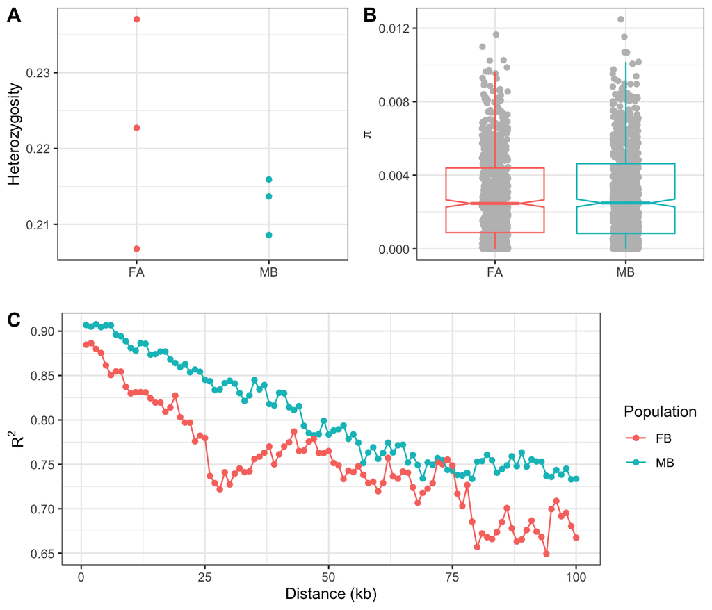

We will work through the figures one at a time. We will start with panel **A**. Let’s first take a look at our data:

```r
het
```

```
## # A tibble: 6 x 5
##   INDV            `O(HOM)` `E(HOM)` N_SITES     F
##   <chr>              <dbl>    <dbl>   <dbl> <dbl>
## 1 2014_SOL_MG4955  1226583  940239. 1549845 0.470
## 2 2014_SOL_MG4956  1219043  940519. 1550336 0.457
## 3 2014_SOL_MG4957  1220962  943362. 1557166 0.452
## 4 2014_SOL_MG4972  1228793  939952. 1549131 0.474
## 5 2014_SOL_MG4973  1209545  943830. 1556138 0.434
## 6 2014_SOL_MG4974  1184876  941554. 1553018 0.398
```

```r
het$Heterozygosity <- 1-(het$`O(HOM)`/het$N_SITES) #The back ticks get around the parentheses in the variable name
het$Population <- c(rep("MB",3),rep("FA",3)) #Know from previously that the first three individuals are from MB
```

For the rest of this course we will be using ggplot2 for our plots - if you have no experience using this package, take 5-10 minutes to familiarise yourself by searching for an online tutorial. Here is one example:

http://www.noamross.net/blog/2012/10/5/ggplot-introduction.html

Basically, `ggplot()` builds up a plot in layers. We first tell R *what* we want to plot, then we tell it *how* to plot it (e.g. with points, boxplot etc.)

We can use ggplot2 to plot heterozygosity against population. We will start off defining the aesthetics, which produces a blank plot. by using the function `geom_point()`, as follows:

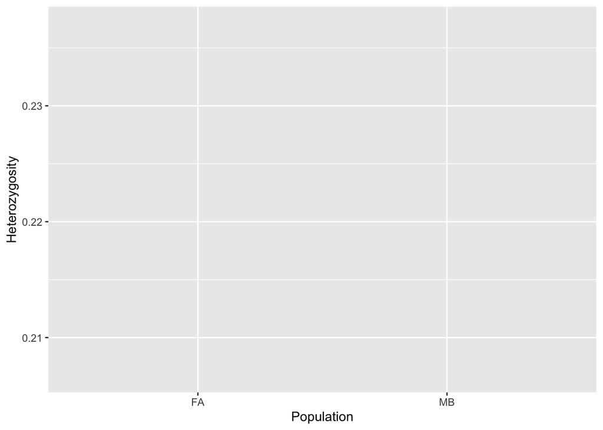

```r
#Make a plot
A <- ggplot(het,aes(x = Population, y = Heterozygosity))

#Call the plot up
A
```

Can you figure out how to now tell ggplot to add points to the plot?

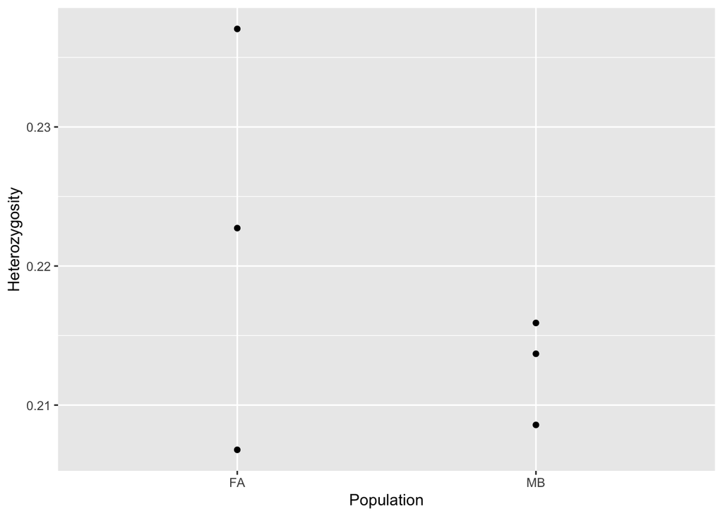

```r
A <- ggplot(het,aes(x = Population, y = Heterozygosity)) +
  geom_point()

A
```

This is already pretty close to what we are after. We just need to colour the points by population:

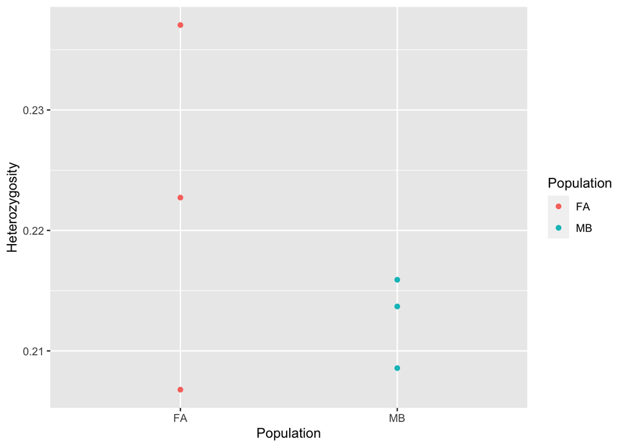

```r
A <- ggplot(het,aes(x = Population, y = Heterozygosity, col = Population)) +
  geom_point()

A
```

Now we need to change the background colour. I did this by adding a layer called `theme_bw()`. Check out ggplots “themes” online for more:

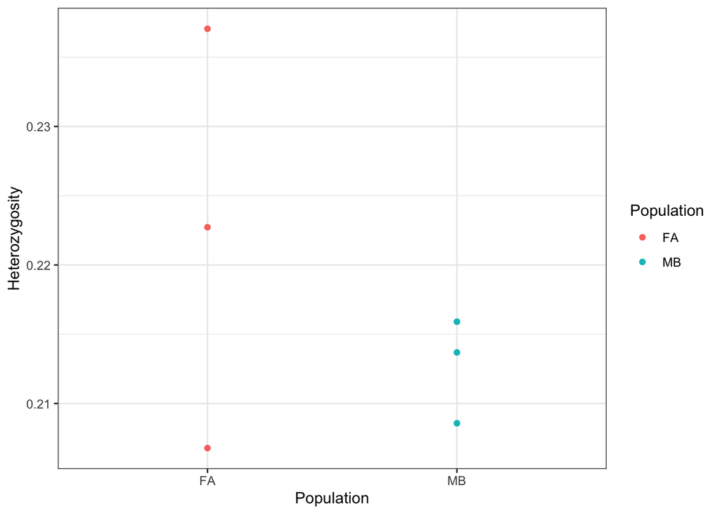

```r
A <- ggplot(het,aes(x = Population, y = Heterozygosity, col = Population)) +
  geom_point()+
  theme_bw()

A
```

Remove the x axis label and the legend:

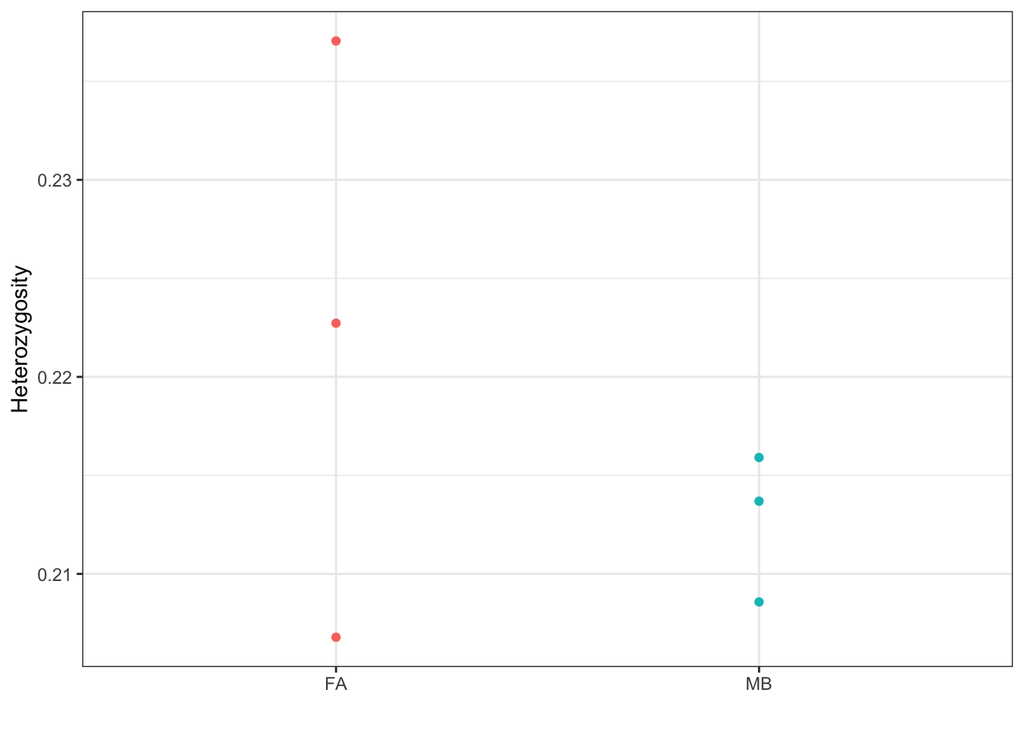

```r
A <- ggplot(het,aes(x = Population, y = Heterozygosity, col = Population)) +
  geom_point()+
  theme_bw()+
  theme(legend.position = "none")+
  xlab("")

A
```

And we’re there! Now let’s move onto panel B, which is slightly more complicated. Again, we first look at the data. Remember we have two data frames for the nucleotide diversity data - one for each population:

```r
pi_MB
```

```
## # A tibble: 847 x 5
##    CHROM BIN_START BIN_END N_VARIANTS       PI
##    <chr>     <dbl>   <dbl>      <dbl>    <dbl>
##  1 ChLG1         1  200000       1136 0.00298
##  2 ChLG1    200001  400000         50 0.000130
##  3 ChLG1    400001  600000        235 0.000587
##  4 ChLG1    600001  800000       1141 0.00305
##  5 ChLG1   1000001 1200000        365 0.000974
##  6 ChLG1   1200001 1400000        749 0.00198
##  7 ChLG1   1600001 1800000        535 0.00155
##  8 ChLG1   1800001 2000000        624 0.00163
##  9 ChLG1   2200001 2400000        556 0.00130
## 10 ChLG1   2400001 2600000        842 0.00222
## # … with 837 more rows
```

```r
pi_FA
```

```
## # A tibble: 847 x 5
##    CHROM BIN_START BIN_END N_VARIANTS       PI
##    <chr>     <dbl>   <dbl>      <dbl>    <dbl>
##  1 ChLG1         1  200000        404 0.000987
##  2 ChLG1    200001  400000         12 0.000029
##  3 ChLG1    400001  600000        240 0.000716
##  4 ChLG1    600001  800000       1163 0.00316
##  5 ChLG1   1000001 1200000        155 0.000354
##  6 ChLG1   1200001 1400000        561 0.00147
##  7 ChLG1   1600001 1800000        454 0.00105
##  8 ChLG1   1800001 2000000        556 0.000996
##  9 ChLG1   2200001 2400000        184 0.000325
## 10 ChLG1   2400001 2600000        571 0.00101
## # … with 837 more rows
```

Because ggplot likes to work from a single data frame, we first need to combine our data from the two populations and add a population ID column:

```r
pi_both <- bind_rows(pi_MB,pi_FA)
pi_both$Population <- c(rep("MB",nrow(pi_MB)),rep("FA",nrow(pi_FA)))
```

Now we are ready to make a plot. We will start with the box plot. Remember that we can use a lot of the same arguments from our previous plot. But this time we will use `geom_boxplot()` instead of `geom_point()`.

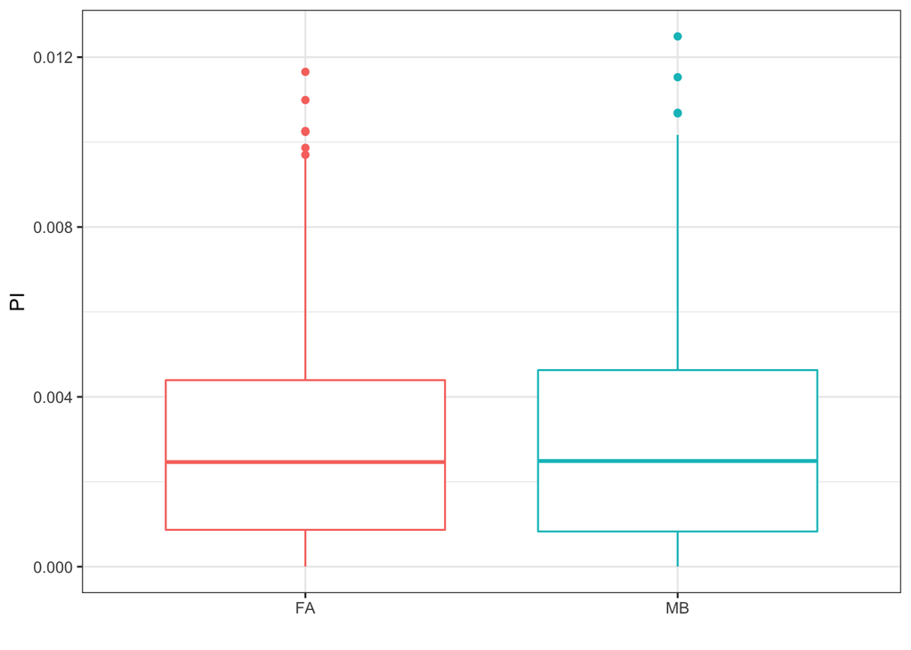

```r
B <- ggplot(pi_both,aes(x = Population, y = PI, col = Population)) +
      geom_boxplot()+
      theme_bw()+
      theme(legend.position = "none")+
      xlab("")
B
```

We can add a notch to the box plot and remove the outliers (google!):

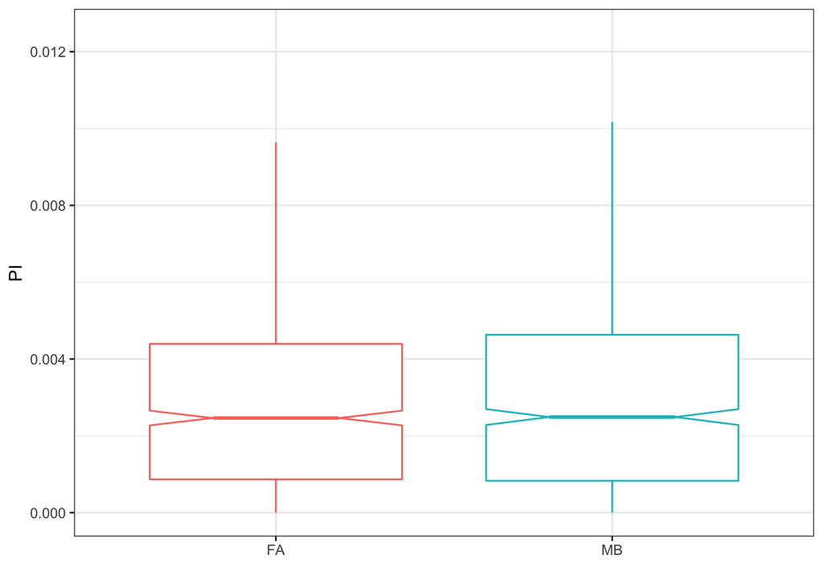

```r
B <- ggplot(pi_both,aes(x = Population, y = PI, col = Population)) +
      geom_boxplot(notch = T,outlier.shape = NA)+
      theme_bw()+
      theme(legend.position = "none")+
      xlab("")
B
```

To add the points behind the box plot we will use the function `geom_jitter`:

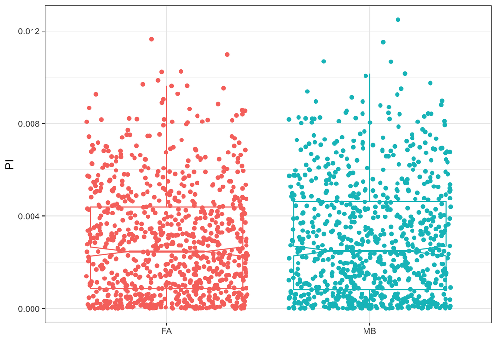

```r
B <- ggplot(pi_both,aes(x = Population, y = PI, col = Population)) +
      geom_boxplot(notch = T,outlier.shape = NA)+
      theme_bw()+
      theme(legend.position = "none")+
      xlab("")+
      geom_jitter()
B
```

There are two problems here. First, the points are getting in the way of the box plots. Second, they have been coloured by population whereas we would like them to be grey. Any idea how we fix these things?

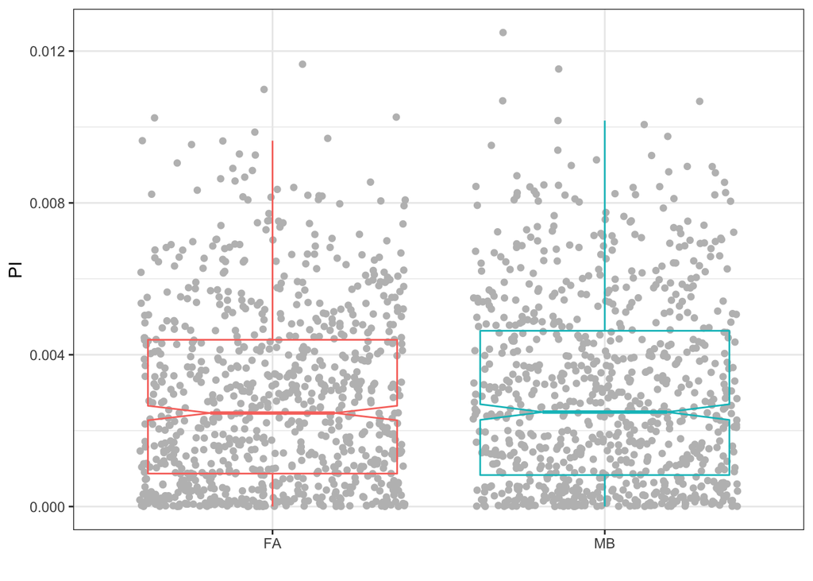

```r
B <- ggplot(pi_both,aes(x = Population, y = PI, col = Population))+
      geom_jitter(col = "grey")+ #Add this before the geom_boxplot() to put the points behind the boxes
      geom_boxplot(notch = T, alpha = 0,outlier.shape = NA)+ #alpha makes the background seethrough
      theme_bw()+
      theme(legend.position = "none")+
      xlab("")

B
```

Getting there… the points in this plot are spread more widely here than in the plot above though. Do you know how we can pack them in more?

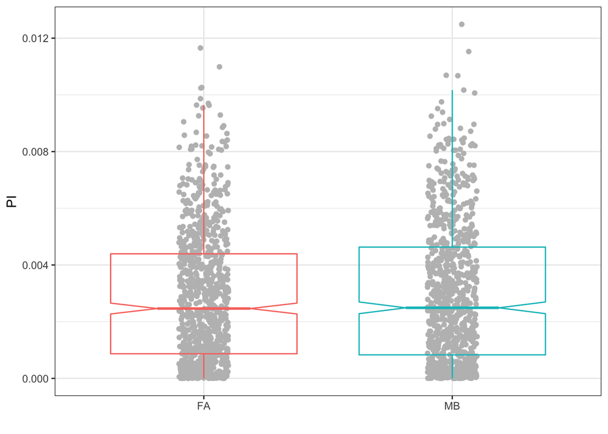

```r
B <- ggplot(pi_both,aes(x = Population, y = PI, col = Population))+
      geom_jitter(col = "grey",width = 0.1)+ #Add this before the geom_boxplot() to put the points behind the boxes
      geom_boxplot(notch = T, alpha = 0,outlier.shape = NA)+ #alpha makes the background seethrough
      theme_bw()+
      theme(legend.position = "none")+
      xlab("")

B
```

Finally, we just need to sort out our y axis. How can we add a symbol? (Hint - look up `expression()`):

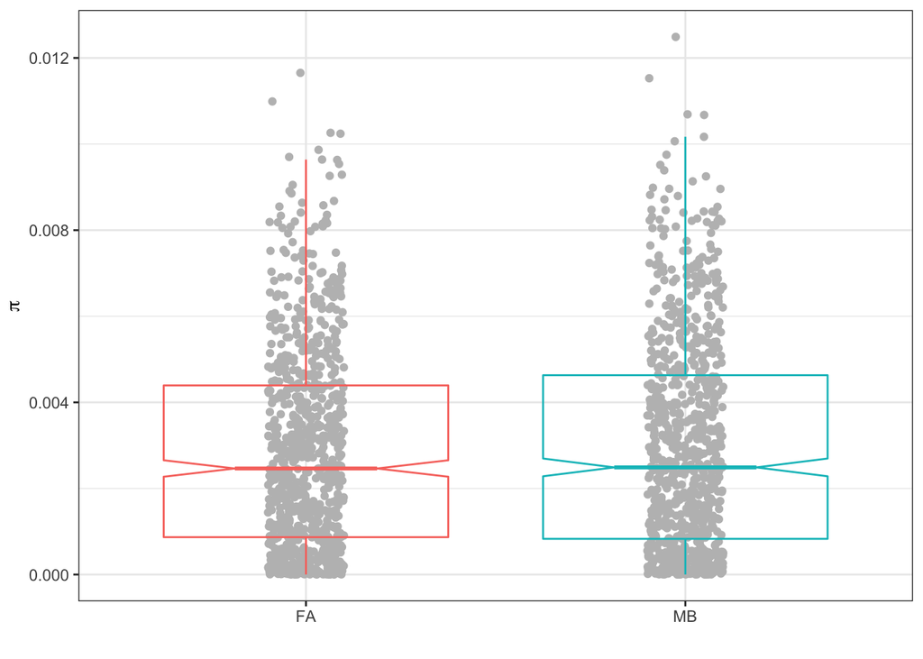

```r
B <- ggplot(pi_both,aes(x = Population, y = PI, col = Population))+
      geom_jitter(col = "grey",width = 0.1)+ #Add this before the geom_boxplot() to put the points behind the boxes
      geom_boxplot(notch = T, alpha = 0,outlier.shape = NA)+ #alpha makes the background seethrough
      theme_bw()+
      theme(legend.position = "none")+
      xlab("")+
      ylab(expression(pi))
B
```

Done! Now we need to make the LD plot and stick them all together. Let’s take another look at the LD data:

```r
ld
```

```
## # A tibble: 200 x 3
##     dist meanR2 pop
##    <dbl>  <dbl> <chr>
##  1  1000  0.907 MB
##  2  2000  0.905 MB
##  3  3000  0.908 MB
##  4  4000  0.905 MB
##  5  5000  0.907 MB
##  6  6000  0.907 MB
##  7  7000  0.896 MB
##  8  8000  0.894 MB
##  9  9000  0.889 MB
## 10 10000  0.881 MB
## # … with 190 more rows
```

This should be relatively simple by now, as we can use the other two plots as templates, and our data is already conveniently formatted in the right way. Let’s start by plotting the points, with distance between marker pairs on the x axis, R2 on the y axis, with colours corresponding to populations.

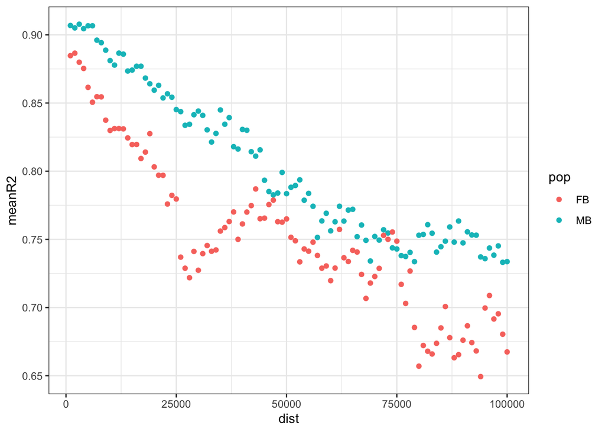

```r
C <- ggplot(ld,aes(x = dist, y = meanR2, col = pop)) +
      geom_point()+
      theme_bw()
C
```

Notice that distance is in bp, whereas we would like it in kb. We can also add the lines:

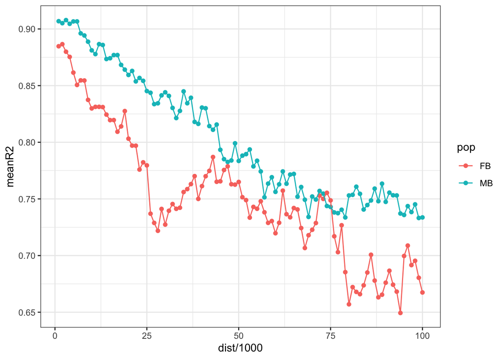

```r
C <- ggplot(ld,aes(x = dist/1000, y = meanR2, col = pop)) +
      geom_point()+
      geom_line()+
      theme_bw()
C
```

All we need to do now is sort out the x axis and y axis labels (hint: you will need `expression()` again for the y axis), and change the legend title. See if you can figure out how to do the the latter on your own (there are multiple ways).

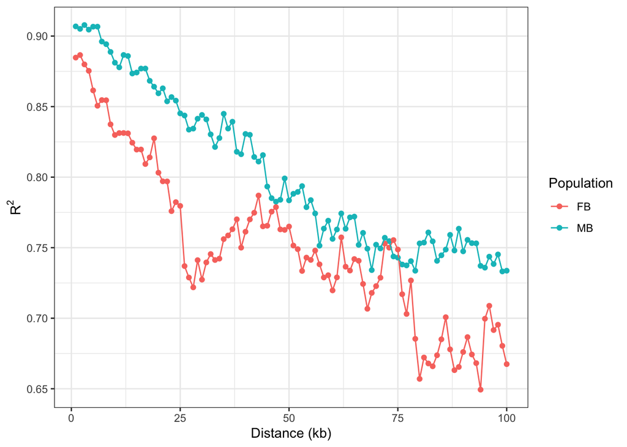

```r
C <- ggplot(ld,aes(x = dist/1000, y = meanR2, col = pop)) +
      geom_point()+
      geom_line()+
      theme_bw()+
      xlab("Distance (kb)")+
      ylab(expression(R^2))+
      scale_colour_discrete(name = "Population")
C
```

Ok, we have done our plots! We now need to make a single, muti-panel plot with labels. Again, there are lots of ways we can do this and this is definitely something you should explore. We will use the `plot_grid()` function from the `cowplot` library. We can just list the plots without specifying anything to do with the layout:

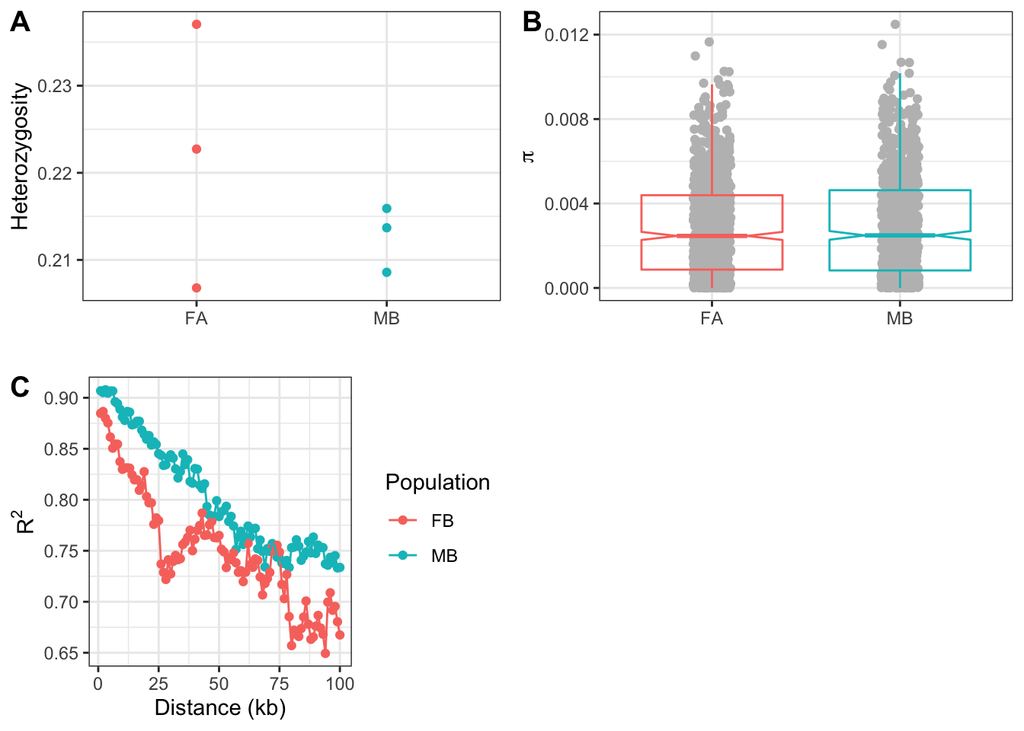

```r
library(cowplot)
plot_grid(A,B,C, labels = "AUTO")
```

However, this leaves a gap in the bottom right. We can alter the layout in an enormous number of ways. Can you figure out what how to plot the first two figures on the top row and the LD figure on the bottom row?

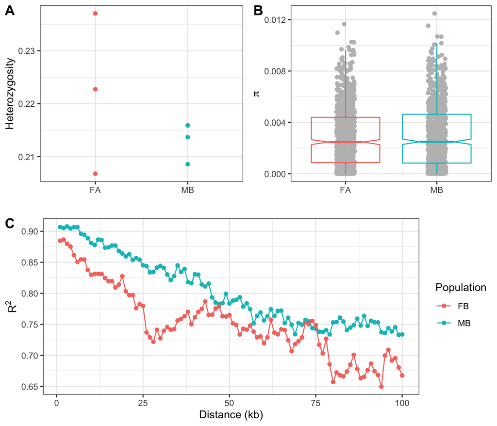

```r
top_row <- plot_grid(A,B,labels = "AUTO")
plot_grid(top_row,C,nrow = 2,labels = c("","C"))
```

## If you’ve finished

- We didn’t perform any filtering steps on our data. Explore filtering based on LD, Hardy-Weinberg and missing data (and anything else you think relevant). How does this affect your results?
- Use `multiplot()` to crease a multi-panelled plot with i) the LD plot on the top, and ii) the heterozygosity plot stretched along the left-hand side, with the pi and LD plots both on the right hand side.
- Plot and test whether nucleotide diversity in each 200kb window is correlated between the two populations. What might explain such a pattern?
- Recreate this plot of nucleotide diversity (200kb windows) for each chromosome, as precisely as you can:

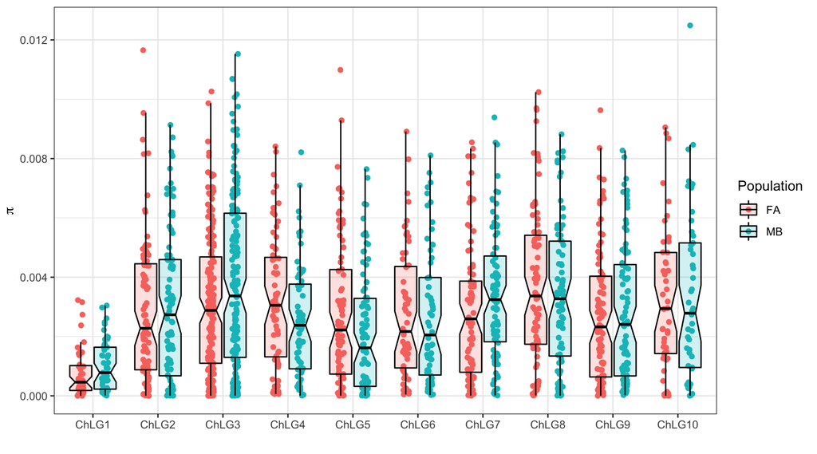